# Bayesian Core - Capítulo 2 - Normal Models

Daysi Febles y Alexander Ramírez

1/2/2017

# Contenido

- Repaso
- Intervalos de Confianza (Regiones de Confianza)
- Prueba de Hipótesis
  - Decisiones $0-1$
  - Factor de Bayes
  - El veto a los *a priori* imprópios

# Contenido

- **Repaso**
- Intervalos de Confianza (Regiones de Confianza)
- Prueba de Hipótesis
  - Decisiones $0-1$
  - Factor de Bayes
  - El veto a los *a priori* imprópios

# Histograma Fig. 2.1.

Relative changes in reported larcenies

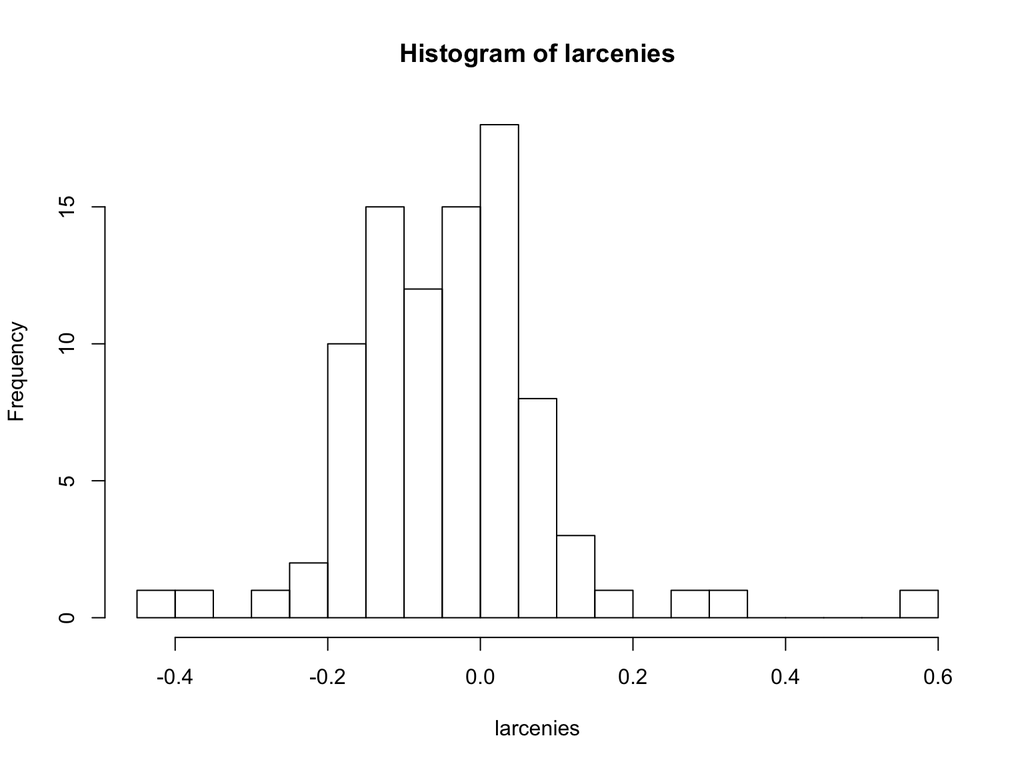

# Spectral image Fig. 2.2.

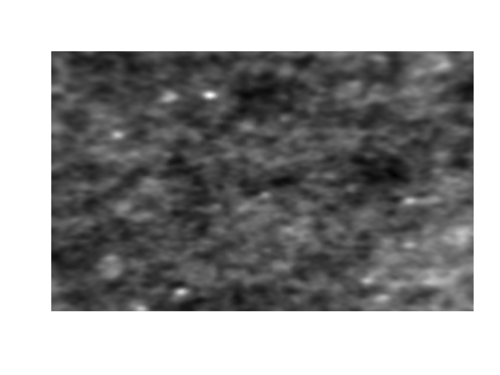

# CMBdata: Histograma y normal ajustada. Fig. 2.3.

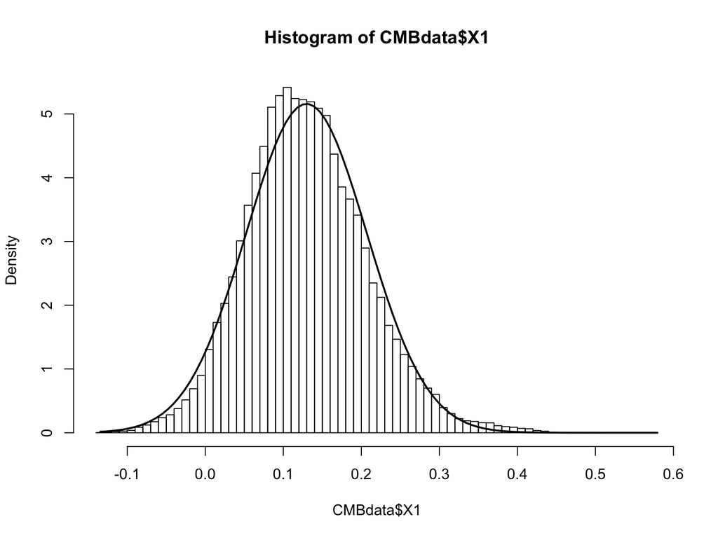

# Subventana aleatoria con histograma de diferencias

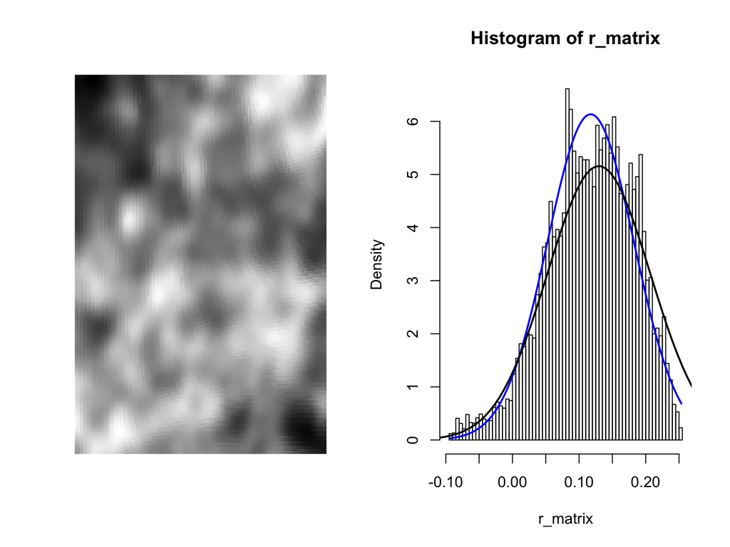

# Contenido

- Repaso
- **Intervalos de Confianza (Regiones de Confianza)**
- Prueba de Hipótesis
  - Decisiones $0-1$
  - Factor de Bayes
  - El veto a los *a priori* imprópios

# Intervalos de Confianza (1)

- La obtención/derivación de los intervalos de confianza (o regiones de confianza en una situación más general) está basada en la distribución posterior $\pi(\theta,\mathcal{D})$.
- Dado que el enfoque Bayesiano trata/procesa al parámetro $\theta$ como una variable aleatoria (se le asigna una distribución), una definición “natural” de la región de confianza sobre $\theta$ es determinar $C(\mathcal{D})$ tal que
  $$\tag{2.9}
  \pi(\theta \in C(\mathcal{D})\ |\ \mathcal{D}) = 1 - \alpha$$
  donde $\alpha$ es un nivel predeterminado así como $0.05$.

# Intervalos de Confianza (2)

- **La grán diferencia, desde una perspectiva tradicional, es que la integración se hace sobre el espacio de parámetros, en lugar del espacio muestral.**
- **La cantidad $1-\alpha$ entonces corresponde a la probabilidad de que un $\theta$ aleatorio pertenece al conjunto $C(\mathcal{D})$, en lugar de la probabilidad de que un conjunto (intervalo) aleatorio contiene el “verdadero” valor del parámetro $\theta$.**

# Intervalos de Confianza (**highest posterior density (HPD) region**)

- Dado este cambio en la interpretación de un conjunto de confianza (también llamado conjunto con credibilidad/creible por los Bayesianos - Credible Regions), la determinación del mejor intervalo resulta más fácil que en el sentido clásico: simplemente corresponde al valor de $\theta$ con el mayor valor para la distribución posterior.
  $$\begin{array}{rl}
  C_{\alpha}^{\pi}(\mathcal{D})=&\{\theta; \pi(\theta\ |\ \mathcal{D})\ge k_{\alpha}\},\\
  C_{\alpha}^{\pi}=&\{\theta; \pi(\theta\ |\ x)\ge k_{\alpha}\}
  \end{array}$$
  donde $k_\alpha$ es el cuantíl tal que se cumple la restricción de cobertura (2.9). Esta región es llamada *highest posterior density (HPD) region* (región de mayor densidad posterior).

# Intervalos de Confianza (**Credible Regions**)

$$C_{\alpha}^{\pi}=\{\theta; \pi(\theta\ |\ x)\ge k_{\alpha}\}$$

- Las regiones de Mayor Densidad Posterior tienen la mayor probabilidad de contener el parámetro $\theta$ para un volumen dado.

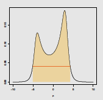

# *A priori* de Jeffreys (Jeffreys prior prior)

$$\pi(\mu, \sigma^2)=1/\sigma^2$$
distribución posterior de $(\mu, \sigma)$
$$\begin{array}{rl}
\mu|\sigma,\bar{x},s_x^2\sim& \mathcal{N}\bigg(\bar{x},\frac{\sigma^2}{n}\bigg),\\
\sigma^2|\bar{x},s_x^2\sim&\mathcal{IG}\bigg(\frac{n-1}{2},\frac{s_x^2}{2}\bigg)
\end{array}$$
entonces
$$\begin{array}{rl}
\pi(\mu|\bar{x},s_x^2)\propto& \displaystyle \int \omega^{1/2} \exp -\omega\frac{n(\bar{x}-\mu)^2}{2}\omega^{(n-3)/2}\exp\{-\omega \ s_x^2/2\}d\omega\\
\propto&[n(\mu-\bar{x})^2+s_x^2]^{-n/2}
\end{array}$$
distribución t-Student con $n-1$ grados de libertad $[\mathcal{T}_{n-1}]$

# Intervalos de Confianza (**normaldata**)

- Para **normaldata**, utilizando el parámetro $\theta=(\mu,\sigma^2)$, la distribución posterior marginal sobre $\mu$ utilizando el *a priori* $\pi(\theta)=1/\sigma^2$ es una distribución *t-Student*
  $$\pi(\mu|\mathcal{D})\propto [n(\mu-\bar{x})^2+s_x^2]^{-n/2}$$
  con $n-1=89$ grados de libertad, como se puede ver en (2.7).

# Intervalos de Confianza (**Normal credibel interval**)

Intervalo sobre $\mu$
$$[\bar{x}\ -\ t_{\alpha/2,n-1}s_x/\sqrt{n(n-1)},\ \bar{x}\ +\ t_{\alpha/2,n-1}s_x/\sqrt{n(n-1)}]$$

- La región de confianza correspondiente al $95\%$ para $\mu$ es el intervalo $[-0.070,-0.013]$. Note que como el $0$ no pertenece al intervalo, uno puede sentir justificado el reporte de un decrecimiento en el número robos entre 1991 y 1995.

# Intervalos de Confianza (**Cálculos**)

```r
alpha<-.05
n<-length(larcenies)
xbar<- mean(larcenies)
sx<- sd(larcenies)
prob<-qt(1-alpha/2,df=n-1)
c(xbar-prob*sx/sqrt(n),xbar+prob*sx/sqrt(n))
```

```
## [1] -0.06966541 -0.01285346
```

# Intervalos de Confianza (**Nota**)

- Mientras que la forma de un intervalo de confianza Bayesiano óptimo es fácilmente derivable, el cálculo de la cota $k_\alpha$ o el conjunto $C(\mathcal{D})$ puede ser muy retador “to allow an analytic construction outside conjugate setups”

# Intervalos de Confianza (**Ejemplo 2.1.**)

Cuando la distribución *a priori* no es conjugada, la distribución posterior no se comporta bien necesariamente. Por ejemplo, si la distribución normal $\mathcal{N}(\mu,1)$ es reemplazada por la distribución de Cauchy, $\mathcal{C}(\mu,1)$, en la verosimilitud
$$l(\mu|\mathcal{D})=\pi(\mathcal{D}\ |\ \theta)=\prod_{i=1}^{n}f_\mu(x_i)=\frac{1}{\pi^n\prod_{i=1}^n(1+(x_i-\mu)^2)},$$
no hay un *a priori* conjugado disponible y podemos, por ejemplo, considerar un *a priori* normal para $\mu$, digamos $\mathcal{N}(0,10)$. La distribución posterior, entonces, es proporcional a
$$\tilde\pi(\mu|\mathcal{D})=\frac{\exp(-\mu^2/20)}{\prod_{i=1}^{n}(1+(x_i-\mu)^2)}.$$

# Intervalos de Confianza (**Ejemplo 2.1.**) (Cont.)

Una solución analítica de $\tilde\pi(\mu|\mathcal{D})$ no es posible, sólo numérica, y el cálculo de una cota apropiada $k_\alpha$ requiere un nivel extra de cómputos numéricos para obtener la cobertura correcta.

# Intervalos de Confianza (**Ejemplo 2.1.**) (Cont.)

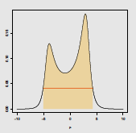

Fig 2.5. Distribución posterior de $\mu$ para una distribución *a priori* $\mathcal{N}(0,10)$ y una región HPD de $95\%$.

# Intervalos de Confianza (**Nota de cierre**)

> Dado que la distribución posterior no es necesariamente unimodal, la región HPD puede incluir varios conjuntos no relacionados (disconnected), como se ilustra en el Ejemplo 2.1. Esto puede parecer contraintuitivo desde el punto de vista clásico, pero se debe interpretar como un indicador de indeterminación, ya sea en los datos o en la distribución *a priori*, acerca de los posibles valores del parámetro $\theta$. Note también que las regiones HPD no son independientes de la selección de la medida de referencia que define el volumen (o superficie).

# Contenido

- Repaso
- Intervalos de Confianza (Regiones de Confianza)
- **Prueba de Hipótesis**
  - Decisiones $0-1$
  - Factor de Bayes
  - El veto a los *a priori* imprópios

# Prueba de Hipótesis

- Decidir la validez de algunas premisas o restricciones sobre el parámetro $\theta$ es una gran parte del trabajo del estadístico.
  $$H_0:\theta \in \Theta_0\ \text{ versus }\ H_1:\theta\notin\Theta_0$$
- Como el resultado del proceso de decisión es claro (*clearcut*), binario, aceptar (representado por 1) o rechazar (representado por 0), la construcción y la evaluación de los procedimientos es crucial.
  $$\mathcal{D}=\{0,1\}$$
- Mientras que la solución Bayesiana es formalmente muy cercana a un estadístico de la razón de la verosimilitud, sus valores numéricos frecuentemente difieren fuertemente de las soluciones clásicas.

# Contenido

- Repaso
- Intervalos de Confianza (Regiones de Confianza)
- Prueba de Hipótesis
  - **Decisiones $0-1$**
  - Factor de Bayes
  - El veto a los *a priori* imprópios

# Decisiones $0-1$ (**Función de pérdida 0-1**)

Vamos a formalizar la premisa como espacios de parámetros restringidos, denotado como $\theta\in\Theta_0$. Por ejemplo, $\theta>0$ corresponde a $\Theta_0=\mathbb{R}^+$.

El enfoque estándar de Neyman Pearson para pruebas de hipótesis se basa en la función de pérdida $0-1$ que penaliza todos los errores igualmente: Si consideramos la prueba de la Hipótesis Nula $H_0: \theta\in\Theta_0$ versus $H_1: \theta\notin\Theta_0$ y denotamos por $d\in\{0,1\}$ la decisión que toma el estadístico y por $\delta$ el procedimiento de decisión correspondiente, la función de pérdida rudimentaria
$$L(\theta,d)=\Bigg\{
\begin{array}{ll}
1-d &\text{si } \theta\in\Theta_0\\
d &\text{si no}
\end{array}$$

# Decisiones $0-1$ (**Función de pérdida 0-1**) (Cont.)

y el riesgo asociado
$$\begin{array}{rl}
R(\theta,\delta) = & \mathbb{E}_\theta[L(\theta,\delta(x))]\\
= & \displaystyle\int_\chi L(\theta,\delta(x))f_\theta(x)dx\\
= & \bigg\{
\displaystyle\begin{array}{lr}
P_\theta(\delta(x)=0), \text{ si }\theta\in\Theta_0\\
P_\theta(\delta(x)=1), \text{ si no}
\end{array}
\end{array}$$
donde $x$ denota los datos $\mathcal{D}$ disponibles.

# Decisiones $0-1$ (**Función de pérdida 0-1**) (Cont.)

Bajo la función de pérdida $0-1$, el criterio de decisión de Bayes (estimador) asociado con la distribución *a priori* $\pi$ es
$$\delta^\pi(x)=\Bigg\{
\begin{array}{lr}
1, \text{ si }P^\pi(\theta\in\Theta_0|x)>P^\pi(\theta\notin\Theta_0|x)\\
0, \text{ si no}
\end{array}$$
Este estimador se justifica fácilmente sobre una base intuitiva dado que se escoge la hipótesis con la probabilidad posterior mayor.

# Decisiones $0-1$ (**Función de pérdida 0-1 ponderada**)

Una generalización de la pérdida mencionada anteriormente es la penalización de los errores de una manera diferente cuando la hipótesis nula es verdadera en lugar de cuando es falsa a través de la función de pérdida $0-1$ ponderada ($a_0,a_1>0$), es decir, Pérdida ponderada $(a_0-a_1)$
$$L_{a_0,a_1}(\theta,d)= \Bigg \{
\begin{array}{ll}
a_0, &\text{ si }\ \theta\in\Theta_0\ \text{ y }\ d=0,\\
a_1, &\text{ si }\ \theta\in\Theta_1\ \text{ y }\ d=1,\\
0,&\text{ si no }
\end{array}$$

# Decisiones $0-1$ (**Ejercicio 2.18.**)

Muestre que, bajo la función de pérdida $L_{a_0,a_1}$, el estimador de Bayes asociado con la distribución *a priori* $\pi$ es dada por
$$\delta^\pi(x)=\Bigg\{
\begin{array}{ll}
1, &\text{ si }\ P^\pi(\theta\in\Theta_0|x)>\displaystyle \frac{a_1}{a_0+a_1},\\
0,&\text{ si no }
\end{array}$$

# Decisiones $0-1$ (**Ejercicio 2.18. - Solución**)

Sea
$$L_{a_0,a_1}(\theta,d)= \Bigg \{
\begin{array}{ll}
a_0, &\text{ si }\ \theta\in\Theta_0\ \text{ y }\ d=0,\\
a_1, &\text{ si }\ \theta\in\Theta_1\ \text{ y }\ d=1,\\
0,&\text{ si no }
\end{array}$$
siendo $d$ la decisión que toma el estadístico (analista) y $\delta$ es el proceso de decisión. La pérdida esperada de la densidad posterior es
$$\mathbb{E}[L_{a_0,a_1}(\theta,d)|x] = \bigg\{
\begin{array}{rl}
a_0\ P^\pi(\theta\in\Theta_0|x)\text{, si } d=0\\
a_1\ P^\pi(\theta\in\Theta_1|x)\text{, si } d=1\\
\end{array}$$

# Decisiones $0-1$ (**Ejercicio 2.18. - Solución**)

La decisión que minimiza la pérdida posterior es $d=1$ cuando
$$\begin{array}{rl}
a_0\ P^\pi(\theta\in\Theta_0|x) > & a_1\ P^\pi(\theta\in\Theta_1|x) \\
a_0\ P^\pi(\theta\in\Theta_0|x) > & a_1\ [1-P^\pi(\theta\in\Theta_0|x)]\\
a_0\ P^\pi(\theta\in\Theta_0|x) > & a_1\ -\ a_1P^\pi(\theta\in\Theta_0|x)\\
a_0\ P^\pi(\theta\in\Theta_0|x) + a_1P^\pi(\theta\in\Theta_0|x) > & a_1\ \\
(a_0+a_1)\ P^\pi(\theta\in\Theta_0|x) > & a_1\ \\
\ P^\pi(\theta\in\Theta_0|x) > & \displaystyle\frac{a_1}{a_0+a_1}\ \\
\end{array}$$
y $0$ en otro caso.

# Decisiones $0-1$ (**Nota**)

Para esta clase de funciones de pérdida, la hipótesis nula $H_0$ se rechaza cuando la probabilidad posterior de $H_0$ es muy pequeña, el nivel de aceptación $a_1/(a_0+a_1)$ se está determinando por la escogencia de ($a_0,a_1$).

# Decisiones $0-1$ (**Ejercicio 2.19.**)

Cuando $\theta\in\{\theta_0,\theta_1\}$, muestre que el procedimiento Bayesiano sólo depende de la razón/ratio $(1-\varrho_0)f_{\theta_1}/\varrho_0f_{\theta_0}(x)$, donde $\varrho_0$ es el peso *a priori* sobre $\theta_0$.

# Decisiones $0-1$ (**Ejercicio 2.19. - Solución**)

En este caso $\pi$ le asigna masa $\varrho_0$ a un punto $\theta_0$ y le asigna por otra parte la masa $(1-\varrho_0)$ a $\theta_1$, entonces
$$\begin{array}{rl}
P^\pi(\theta=\theta_0)=&\displaystyle \frac{\varrho_0 f_{\theta_0}(x)}{\varrho_0 f_{\theta_0}(x)\ +\ \varrho_1 f_{\theta_1}(x)}\\
=&\displaystyle \frac{\varrho_0 f_{\theta_0}(x)}{\varrho_0 f_{\theta_0}(x)\ +\ (1-\varrho_0) f_{\theta_1}(x)}\\
=&\displaystyle \frac{1}{1\ +\ \displaystyle \frac{(1-\varrho_0) f_{\theta_1}(x)}{\varrho_0 f_{\theta_0}(x)}}
\end{array}$$

# Decisiones $0-1$ (**Falta de Robustez**)

Para $x\sim\mathcal{N}(\mu,\sigma^2)$ y $\mu\sim\mathcal{N}(\xi,\tau^2)$, recordemos que $\pi(\mu|x)$ es la distribución normal con $\mathcal{N}(\xi(x),w^2)$ con
$$\xi(x)=\frac{\sigma^2\xi+\tau^2x}{\sigma^2+\tau^2}\ \text{ y }\ \omega^2=\frac{\sigma^2\tau^2}{\sigma^2+\tau^2}$$
Para probar $H_0:\mu<0$ calculamos
$$\begin{array}{rl}
P^\pi(\mu<0|x) = & \displaystyle P^\pi\Bigg(\frac{\mu-\xi(x)}{\omega}<\frac{-\xi(x)}{\omega} \Bigg) \sim \mathcal{N}(0,1)\\
= & \displaystyle \Phi\bigg(\frac{-\xi(x)}{\omega}\bigg)
\end{array}$$

# Decisiones $0-1$ (**Falta de Robustez**) (Cont.)

Si $z_{a_0,a_1}$ es el cuantil $\frac{a_1}{a_0+a_1}$ de una distribución normal $\mathcal{N}(0,1)$ (por ejemplo, $\Phi(z_{a_0,a_1})=\frac{a_1}{a_0+a_1}$), aceptamos la hipótesis nula $H_0$ cuando
$$-\xi(x)>z_{a_0,a_1}\omega$$
la cota de aceptación superior es
$$x\le-\frac{\sigma^2}{\tau^2}\xi - \bigg(1+ \frac{\sigma^2}{\tau^2} \bigg)z_{a_0,a_1}\omega$$
Esto ilustra una vez más la falta de robustez de la distribución *a priori* conjugada: Esta cota puede ser cualquier real cuando $\xi$ varía en $\mathbb{R}$.

# Decisiones $0-1$ (**Ejercicio 2.20.**)

Muestre que el límite de la probabilidad posterior $P^\pi(\mu<0|x)$ cuando $\xi$ tiende a $0$ y $\tau$ tiende a $\infty$ es $\Phi(-x/\sigma)$.

# Decisiones $0-1$ (**Ejercicio 2.20. - Solución**)

Para $x\sim\mathcal{N}(\mu,\sigma^2)$ y $\mu\sim\mathcal{N}(\xi,\tau^2)$, recordemos que $\pi(\mu|x)$ es la distribución normal con $\mathcal{N}(\xi(x),w^2)$ con $P^\pi(\mu<0|x)=\Phi\bigg(\frac{-\xi(x)}{\omega}\bigg)$
$$\xi(x)=\frac{\sigma^2\xi+\tau^2x}{\sigma^2+\tau^2}\ \text{ y }\ \omega^2=\frac{\sigma^2\tau^2}{\sigma^2+\tau^2}$$

# Decisiones $0-1$ (**Ejercicio 2.20. - Solución**)

Entonces
$$\begin{array}{rl}
\Phi\bigg(\frac{-\xi(x)}{\omega}\bigg)=&\Phi\Bigg(-\displaystyle \frac{\displaystyle \sigma^2\xi+\tau^2x}{\sigma^2+\tau^2}\Bigg/{\displaystyle\sqrt{\frac{\sigma^2\tau^2}{\sigma^2+\tau^2}}}\Bigg)\\
=&\Phi\Bigg(-\displaystyle \frac{\displaystyle \sigma^2\xi+\tau^2x}{\sqrt{\sigma^2+\tau^2} \sqrt{\sigma^2\tau^2}}\Bigg)\\
\end{array}$$
ahora vamos a ver que pasa cuando $\xi\to 0$
$$\lim_{\xi\to 0}-\displaystyle \frac{\displaystyle \sigma^2\xi+\tau^2x}{\sqrt{\sigma^2+\tau^2} \sqrt{\sigma^2\tau^2}}=-\displaystyle \frac{\displaystyle \tau^2x}{\sqrt{\sigma^2+\tau^2} \sqrt{\sigma^2\tau^2}}$$

# Decisiones $0-1$ (**Ejercicio 2.20. - Solución**)

ahora vamor a ver que pasa cuando $\tau\to\infty$
$$\begin{array}{rl}
\displaystyle \lim_{\tau\to\infty} -\displaystyle \frac{\displaystyle \tau^2x}{\sqrt{\sigma^2+\tau^2} \sqrt{\sigma^2\tau^2}}=& \displaystyle \lim_{\tau\to\infty}-\frac{\displaystyle \tau^2x}{\sqrt{\tau^2(\frac{\sigma^2}{\tau^2}+1}) \sigma\ \tau} \\
=&\displaystyle \lim_{\tau\to\infty}-\frac{\displaystyle \tau^2x}{\tau^2\ \sigma \sqrt{\frac{\sigma^2}{\tau^2}+1}}\\
=&\displaystyle \lim_{\tau\to\infty}-\frac{\displaystyle x}{\sigma \sqrt{\frac{\sigma^2}{\tau^2}+1}}=-\frac{x}{\sigma}
\end{array}$$

# Contenido

- Repaso
- Intervalos de Confianza (Regiones de Confianza)
- Prueba de Hipótesis
  - Decisiones $0-1$
  - **Factor de Bayes**
  - El veto a los *a priori* imprópios

# Factor de Bayes

Una noción central a las pruebas Bayesianas es el *Factor de Bayes*
$$B_{10}^\pi=\displaystyle \frac{\frac{P^\pi(\theta\in\Theta_1|x)}{P^\pi(\theta\in\Theta_0|x)}}{\frac{P^\pi(\theta\in\Theta_1)}{P^\pi(\theta\in\Theta_0)}}=\displaystyle \frac{\frac{P^\pi(\mathcal{M}_1|x)}{P^\pi(\mathcal{M}_0|x)}}{\frac{P^\pi(\mathcal{M}_1)}{P^\pi(\mathcal{M}_0)}}$$
que corresponde a las posibilidades clásica (classical odds) o razón de verosimilitud, la diferencia está en que los parámetros se integran en lugar de maximizarce bajo cada modelo $\mathcal{M}_1$ versus $\mathcal{M}_0$.

Los procedimientos de Prueba de Hipótesis depende de $P^\pi(\theta\in\Theta_0|x)$ o alternativamente del *Factor de Bayes*, en la ausencia de parámetros $a_0$ y $a_1$ de la función de pérdida.

# Factor de Bayes (**Escala de Evidencia de Jeffreys**)

Dado que es una simple transformada uno a uno de la probabilidad posterior, se puede usar para pruebas Bayesianas sin utilizar una función de pérdida específica, por ejemplo usando la escala de evidencia de Jeffreys:

- Si $0\le\log_{10}(B_{10}^\pi)<\frac{1}{2}$ la evidencia en contra $H_0$ es débil
- Si $\frac{1}{2}\le\log_{10}(B_{10}^\pi)<1$ la evidencia es sustancial
- Si $1\le\log_{10}(B_{10}^\pi)<2$ la evidencia es fuerte y
- Si $\log_{10}(B_{10}^\pi)\ge2$ la evidencia es decisiva

# Factor de Bayes (**Escala de Evidencia de Jeffreys**) (Cont.)

A pesar de que esta escala está lejos de ser justificada bajo principios estrictos, provee una referencia para evaluar las hipótesis sin necesidad de definir las probabilidades *a priori* $H_0:\theta\in\Theta_0$ versus $H_1:\theta\in\Theta_1$, lo cual es una de las ventajas de utilizar el *Factor Bayesiano*.

En general, el *Factor de Bayes* obviamente depende de la información *a priori*, pero todavía se considera una respuesta Bayesiana objetiva en parte por que elimina la influencia del modelo *a priori* y enfatiza el rol de las observaciones.

# Factor de Bayes (**Reparametrización**)

Alternativamente, se puede notar (perceived) como una razón de verosimilitud Bayesiana dado que si $\pi_0$ y $\pi_1$ son distribuciones *a priori* bajo $H_0$ y $H_1$, respectivamente y si $P^\pi(\theta\in\Theta_0)=P^\pi(\theta\in\Theta_1)=\frac{1}{2}$, $B_{10}^\pi$, entonces dado un *a priori*
$$\pi(\theta)=P^\pi(\theta\in\Theta_0)\times\pi_0(\theta)+P^\pi(\theta\in\Theta_1)\times\pi_1(\theta)$$
se puede expresar como
$$B_{10}^\pi=\frac{\displaystyle\int_{\Theta_1}f_\theta(x)\pi_1(\theta)d\theta}{\displaystyle\int_{\Theta_0}f_\theta(x)\pi_0(\theta)d\theta}=\frac{m_1(x)}{m_0(x)}$$
en la cual reemplazamos las verosimilitudes con las marginales bajo ambas hipótesis.

# Factor de Bayes (**Hipótesis nula puntual**)

Cuando la hipótesis que se va a probar es una hipótesis nula puntual, $H_0:\theta=\theta_0$, hay dificultades en la construcción de un procedimiento Bayesiano, dado que, para una distribución *a priori* contínua $\pi$
$$P^\pi(\theta=\theta_0)=0$$

# Factor de Bayes (**Hipótesis nula puntual**) (Cont.)

Obviamente, las hipótesis nulas puntuales se pueden criticar y considerar como artificiales e imposibles de probar (*¿Con cuanta frecuencia se puede distinguir entre $\theta=0$ de $\theta=0.0001$?!*), sin embargo también se deben realizar como parte de los requerimientos del análisis estadístico del día a día y también se pueden ver como una representación conveniente de algunos problemas de escogencia del modelo (model choice problems) que serán tratados luego.

# Factor de Bayes (**Hipótesis nula puntual**) (Cont.)

La prueba de hipótesis nulas puntuales ameritan una modificación de la distribución *a priori* tal que cuando se prueba $H_0:\theta\in\Theta_0$ versus $H_1:\theta\in\Theta_1$, se cumple que
$$\pi(\Theta_0)>0\ \ y \ \ \pi(\Theta_1)>0$$
independientemente de los cálculos (measures) de $\Theta_0$ y $\Theta_1$ para la distribución *a priori* original, lo cual significa que la distribución *a priori* se puede descomponer como
$$\pi(\theta)=P^\pi(\theta\in\Theta_0)\times\pi_0(\theta)+P^\pi(\theta\in\Theta_1)\times\pi_1(\theta)$$
con pesos positivos en ambos conjuntos $\Theta_0$ y $\Theta_1$.

# Factor de Bayes (**Nota**)

- Note que esta modificación tiene sentido tanto desde el punto de vista de la información como operativo. Si $H_0:\theta=\theta_0$, el hecho de que la hipótesis es puesta a prueba implica que $\theta=\theta_0$ es una posibilidad y trae información *a priori* adicional sobre el parámetro $\theta$.
- Además, si se prueba $H_0$ y es aceptada, esto significa, en la mayoría de los casos, que el modelo (reducido) bajo $H_0$ se utilizará en lugar del modelo (completo) considerado anteriormente.
- Entonces, una distribución *a priori* bajo el modelo reducido debe estar disponible para inferencias posteriores potenciales. (Obviamente, el hecho de que esta inferencia posterior depende de la selección de la hipótesis nula $H_0$ también se debería tomar en consideración.)

# Factor de Bayes (**Masa de Dirac**)

En el caso especial $\Theta_0=\{\theta_0\}$, $\pi_0$ es la masa de *Dirac* en $\theta_0$, que significa que $P^{\pi_0}(\theta=\theta_0)=1$, y se requiere introducir un peso *a priori* separado de $H_0$, digamos,
$$\rho=P(\theta=\theta_0)\ \text{ y }\ \pi(\theta)=\rho\ 1_{\theta_0}(\theta)\ +\ (1-\rho)\pi_1(\theta)$$
entonces,
$$\begin{array}{rl}
\displaystyle \pi(\Theta_0|x)&=\displaystyle \frac{f_{\theta_0}(x)\rho}{\displaystyle\int f_\theta(x)\pi(\theta)d\theta} \\
&=\displaystyle \frac{f_{\theta_0}(x)\rho}{f_{\theta_0}(x)\rho\ +\ (1-\rho)m_1(x)}
\end{array}$$

con
$$m_1(x)=\int_{\Theta_1}f(x|\theta)\pi_1(\theta)d\theta$$

# Factor de Bayes (**Masa de Dirac**)

Para $x\sim\mathcal{N}(\mu,\sigma^2)$ y $\mu\sim\mathcal{N}(\xi,\tau^2)$, considere la prueba $H_0:\mu=0$. Podemos escoger $\xi$ igual a $0$ si no contamos con información *a priori* adicional. Entonces el *Factor de Bayes* es la razón de las marginales bajo ambas hipótesis, $\mu=0$ y $\mu\ne 0$,
$$\begin{array}{ll}
B_{10}^\pi=\displaystyle \frac{m_1(x)}{f_0(x)}&=\displaystyle \frac{\sigma}{\sqrt{\sigma^2+\tau^2}}\frac{e^{-x^2/2(\sigma^2+\tau^2)}}{e^{-x^2/2\sigma^2}} \\
&=\displaystyle \sqrt{\frac{\sigma^2}{\sigma^2+\tau^2}}\exp\bigg\{\frac{\tau^2x^2}{2\sigma^2(\sigma^2+\tau^2)} \bigg\}
\end{array}$$
y
$$\pi(\mu=0|x)=\bigg[1\ +\ \frac{1-\rho}{\rho} \displaystyle \sqrt{\frac{\sigma^2}{\sigma^2+\tau^2}}\exp\bigg\{\frac{\tau^2x^2}{2\sigma^2(\sigma^2+\tau^2)} \bigg\}\bigg]^{-1}$$
es la probabilidad posterior de $H_0$.

# Factor de Bayes (**Tabla 2.1**)

La Tabla 2.1 ofrece una idea de los valores de la probabilidad posterior cuando la cantidad normalizada $x/\sigma$ varía. Esta probabilidad posterior obviamente depende de la selección de la variancia *a priori* $\tau^2$: La dependencia es en realidad muy severa, como veremos más adelante con la paradoja de *Jeffreys Lindley*.

**Tabla 2.1.** Probabilidad posterior de $\mu=0$ para valores diferentes de $z=x/\sigma$, $\rho=1/2$ y para $\tau=\sigma$ (fila superior), $\tau^2=10\sigma^2$ (fila inferior).

$$\begin{array}{ccccc}
\hline
z & 0 & 0.68 & 1.28 & 1.96 \\ \hline
\pi(\mu=0|z) & 0.586 & 0.557 & 0.484 & 0.351 \\ \hline
\pi(\mu=0|z) & 0.768 & 0.729 & 0.612 & 0.366 \\ \hline
\end{array}$$

# Factor de Bayes (**normaldata**)

Para **normaldata**, si escogemos $\tau$ igual a $0.1$, el *Factor de Bayes* contra $\mu=0$ sólo depende de $\overline{x}_n\sim\mathcal{N}(\mu,\hat\sigma^2/90)$ y es igual a
$$B_{10}^\pi(\overline{x}_n)=\sqrt{\frac{\hat\sigma^2}{\hat\sigma^2+n\tau^2}}\exp\bigg\{\frac{n\tau^2\ \overline{x}^2_n}{2\hat\sigma^2(\hat\sigma^2+n\tau^2)} \bigg\}=0.1481$$
El conjunto de datos, por tanto, favorece la hipótesis nula $H_0:\mu=0$. Sin embargo, otras elecciones de $\tau$ pueden resultar en evaluaciones numéricas diferentes, como se muestra en la Figura 2.6, como el *Factor de Bayes* varía entre $1$ y $0$ así como $\tau$ crece de $0$ a $\infty$.

# Factor de Bayes (**Figura 2.6.**)

A continuación la **Figura 2.6.** con los Datos **normaldata**: Rango del *Factor de Bayes* $B_{10}^\pi$ cuando $\tau$ va de $10^{-4}$ a 10. (El eje $x$ está en escala logarítmica)

# Factor de Bayes (**Figura 2.6.**)

```
## [1] 0.1480872
```

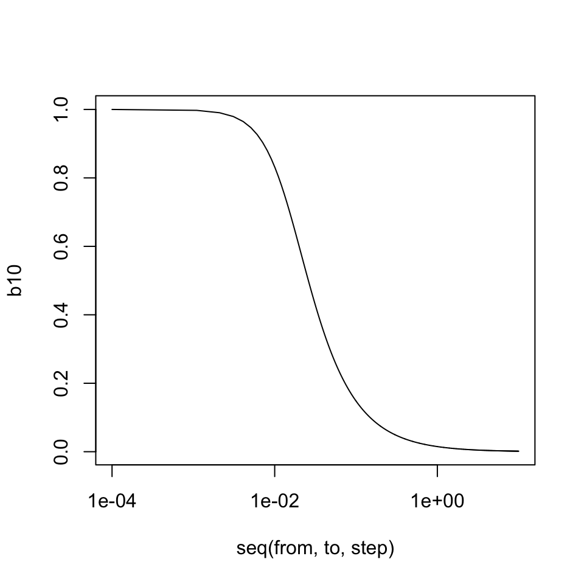

**Figura 2.6.** Datos **normaldata**: Rango del *Factor de Bayes* $B_{10}^\pi$ cuando $\tau$ va de $10^{-4}$ a 10. (El eje $x$ está en escala logarítmica)

# Contenido

- Repaso
- Intervalos de Confianza (Regiones de Confianza)
- Prueba de Hipótesis
  - Decisiones $0-1$
  - Factor de Bayes
  - **El veto a los *a priori* imprópios**

# El veto a los *a priori* imprópios

Desafortunadamente, esta descomposición de la distribución *a priori* en dos sub distribuciones *a priori* genera una seria dificultad relacionada con las distribuciones *a priori* imprópias, que implica en términos prácticos, el veto de su uso en situaciones de prueba (testing situations). De hecho, cuando se utiliza la representación
$$\pi(\theta)=P(\theta\in\Theta_0)\times\pi_0(\theta)+P(\theta\in\Theta_1)\times\pi_1(\theta)$$
los pesos $P(\theta\in\Theta_0)$ y $P(\theta\in\Theta_1)$ son significativos sólo si $\pi_0$ y $\pi_1$ son densidades de probabilidad normalizadas. De lo contrario, no se pueden interpretar como *pesos*.

# El veto a los *a priori* imprópios (Cont.)

Cuando $x\sim\mathcal{N}(\mu,1)$ y $H_0:\mu=0$, la distribución *a priori* imprópia (Jeffreys) es $\pi_1(\mu)=1$; si escribimos
$$\pi(\mu)=\frac{1}{2} 1_{0}(\mu)+\frac{1}{2} \cdotp 1$$
entonces la probabilidad posterior es
$$\pi(\mu=0|x)= \frac{\displaystyle e^{-\frac{x^2}{2}}}{e^{-\frac{x^2}{2}}\ +\ \displaystyle \int_{-\infty}^{\infty}e^{-\frac{(x-\theta)^2}{2}}}=\frac{1}{1+\sqrt{2\pi}\ e^{\frac{x^2}{2}}}$$
Una primera consecuencia de esta elección la probabilidad posterior de $H_0$ es acotada superiormente por
$$\pi(\mu=0|x)\le\frac{1}{(1+\sqrt{2\pi})}=0.285$$

# El veto a los *a priori* imprópios (Cont.)

La Tabla 2.2 provee la evolución (el cambio) de esta probabilidad cuando $x$ se separa del $0$. Un punto interesante es que los valores numéricos, de alguna forma, coinciden con los *p*-valores utilizados en las pruebas de hipótesis clásicas (Casella and Berger, 2001).

**Tabla 2.2.** Probabilidad posterior de $H_0:\mu=0$ para la distribución *a priori* de Jeffrey $\pi_1(\mu)=1$ bajo $H_1$.

$$\begin{array}{cccccc}
\hline
x & 0 & 1.0 & 1.65 & 1.96 & 2.58 \\ \hline
\pi(\mu=0|x) & 0.285 & 0.195 & 0.089 & 0.055 & 0.014 \\ \hline
\end{array}$$

# El veto a los *a priori* imprópios (**Nota**)

> Si estamos interesados en probar $H_0: \theta\le 0$ versus $H_1:\theta>0$ entonces la probabilidad posterior es
> $$\pi(\theta\le 0|x)=\frac{1}{\sqrt{2\pi}}\int_{-\infty}^0 e^{-\frac{(x-\theta)^2}{2}}d\theta=\Phi(-x)$$
> y la respuesta es ahora *exáctamente* el *p*-valor que encontramos en la estadística clásica.

# El veto a los *a priori* imprópios (**Paradoja de Jeffrey**)

La dificultad en el uso de una distribución *a priori* imprópia se relaciona a la llamada paradoja de *Jeffrey Lindley*, un fenómeno que muestra que los argumentos limitantes (limiting arguments) no son válidos en situaciones de pruebas de hipótesis. Por el contrario en estimación, las distribuciones *a priori* no informativas no corresponden mas al límite de inferencias conjugadas. De hecho, para una distribución *a priori* conjugada, la probabilidad posterior
$$\pi(\mu=0|x)=\bigg[1\ +\ \frac{1-\rho_0}{\rho_0} \displaystyle \sqrt{\frac{\sigma^2}{\sigma^2+\tau^2}}\exp\bigg\{\frac{\tau^2x^2}{2\sigma^2(\sigma^2+\tau^2)} \bigg\}\bigg]^{-1}$$
converge a $1$ cuando $\tau$ va a $+\infty$, para cada valor de $x$, como se ilustró en la Figura 2.6. Este procedimiento no informativo, obviamente difiere de la respuesta no informativa previa $[1+\sqrt{2\pi}\exp(x^2/2)]^{-1}$.

# El veto a los *a priori* imprópios (**Dificultad para normalizar**)

El principal obstáculo (bars us) que impide el uso de *a priori* imprópios en uno o dos conjuntos $\Theta_0$ y $\Theta_1$ es una dificultad para normalizar (normalizing difficulty): Si $g_0$ y $g_1$ son medidas (en lugar de probabilidades) sobre los subespacios $\Theta_0$ y $\Theta_1$, la selección de las constantes normalizadoras influencia en *Factor de Bayes*. De hecho, cuando $g_i$ es reemplazada por $c_i g_i (i=0,1)$, donde $c_i$ es una constante arbitraria, el *Factor de Bayes* es multiplicado por $c_0/c_1$.

# El veto a los *a priori* imprópios (**Dificultad para normalizar**)

Entonces, por ejemplo, si el *a priori* de Jeffrey es uniforme y $g_0=c_0$,$g_1=c_1$, la probabilidad posterior
$$\begin{array}{rr}
\displaystyle \pi(\theta\in\Theta_0|x)=&\frac{\displaystyle \rho_0c_0\int_{\Theta_0}f(x|\theta)d\theta}{\displaystyle \rho_0c_0\int_{\Theta_0}f(x|\theta)d\theta\ +\ (1-\rho_0)c_1\int_{\Theta_1}f(x|\theta)d\theta}\\
=&\frac{\displaystyle \rho_0\int_{\Theta_0}f(x|\theta)d\theta}{\displaystyle \rho_0\int_{\Theta_0}f(x|\theta)d\theta\ +\ (1-\rho_0)[c_1/c_0]\int_{\Theta_1}f(x|\theta)d\theta}
\end{array}$$
es completamente determinado por la selección de $[c_0/c_1]$. Esto implica, por ejemplo, que la función $[1+\sqrt{2\pi}\exp(x^2/2)]^{-1}$ obtenida previamente no tiene ninguna validez.

# El veto a los *a priori* imprópios (**CMBdata**)

# El veto a los *a priori* imprópios (**CMBdata**)

Para tomar ventaja de la estructura de este modelo, podemos asumir que $\sigma^2$ es el mismo error de medición bajo ambos modelos y por tanto comparten la misma distribución *a priori*. Esto significa que el *Factor de Bayes*
$$B_{10}^\pi=\frac{\int l(\mu_x,\mu_y,\sigma|\mathcal{D})\pi(\mu_x,\mu_y)\pi_\sigma(\sigma^2)d\sigma^2d\mu_x d\mu_y}{\int l(\mu,\sigma|\mathcal{D})\pi_\mu(\mu)\pi_\sigma(\sigma^2)d\sigma^2d\mu}$$
no depende de la constante de normalización utilizada para $\pi_\sigma(\sigma^2)$ y por tanto todavía podemos utilizar *a priori* imprópios como $\pi_\sigma(\sigma^2)=1/\sigma^2$ en este caso. Adicionalmente, podemos reescribir $\mu_x$ y $\mu_y$ como $\mu_x=\mu-\xi$ y $\mu_y=\mu+\xi$ respectivamente y utilizar un *a priori* de la forma $\pi(\mu,\xi)=\pi_\mu(\mu)\pi_\xi(\xi)$ en la nueva parametrización, así, de nuevo, el mismo *a priori* $\pi_\mu$ se puede utilizar bajo ambas $H_0$ y su alternativa.

# El veto a los *a priori* imprópios (**CMBdata**) (Cont.)

La misma cancelación de la constante de normalización ocurre para $\pi_\mu$ y la selección del *a priori* $\pi_\mu(\mu)=1$ y $\xi\sim\mathcal{N}(0,1)$ nos da que $B_{10}^\pi$ es
$$\scalebox{0.8}{$
\begin{array}{rl}
B_{10}^\pi=&\frac{\displaystyle \int\exp-\frac{n}{2\sigma^2}[(\mu-\xi-\bar{x})^2+(\mu+\xi-\bar{y})^2+S^2]\sigma^{-2n-2}e^{-\xi^2/2}/\sqrt{2\pi}\ d\sigma^2\ d\mu \ d\xi}
{\displaystyle \int\exp-\frac{n}{2\sigma^2}[(\mu-\bar{x})^2+(\mu-\bar{y})^2+S^2]\sigma^{-2n-2}\ d\sigma^2\ d\mu}\\
=&\frac{\displaystyle \int[(\mu-\xi-\bar{x})^2+(\mu+\xi-\bar{y})^2+S^2]^{-n}e^{-\xi^2/2}/\sqrt{2\pi}\ d\mu \ d\xi}
{\displaystyle \int[(\mu-\bar{x})^2+(\mu-\bar{y})^2+S^2]^{-n}\ d\mu}
\end{array}
$}$$

# El veto a los *a priori* imprópios (**CMBdata**) (Cont.)

Donde $S$ denota la media
$$S=\frac{1}{n}\sum_{i=1}^{n}(x_i-\bar{x})^2+\frac{1}{n}\sum_{i=1}^{n}(y_i-\bar{y})^2$$

Mientras que el denominador se puede integrar, el numerador no. Una aproximación numérica de $B_{10}^\pi$ es necesaria. Este asunto será tratado en la Sección 2.4.

# El veto a los *a priori* imprópios (**Ejercicio 2.21.**)

Recordemos que la constante de normalización para la distribución t-Student $\tau(\nu,\mu,\sigma^2)$ es
$$\displaystyle \frac{\frac{\Gamma\bigg(\frac{\nu+1}{2}\bigg)}{\Gamma\big(\frac{\nu}{2}\big)}}{\sigma\sqrt{\nu\pi}}$$

Calcule el valor de la integrar en el denominador de $B_{10}^\pi$ previo.

# El veto a los *a priori* imprópios (**Ejercicio 2.21. - Solución**)

Primero vamos a desarrollar
$$\begin{array}{rl}
(\mu-\bar{x})^2+(\mu-\bar{y})^2=&(\mu^2-2\mu\bar{x}+\bar{x}^2)+(\mu^2-2\mu\bar{y}+\bar{y}^2)\\
=&2\mu^2-2\mu(\bar{x}+\bar{y})+\bar{x}^2+\bar{y}^2\\
=&\vdots\\
=&2[\mu- \big(\frac{\bar{x}+\bar{y}}{2}\big)]^2+\frac{(\bar{x}-\bar{y})^2}{2}
\end{array}$$

# El veto a los *a priori* imprópios (**Ejercicio 2.21. - Solución**)

sustituyendo esta expresión en el denominador de la integral anterior, tenemos
$$\begin{array}{ll}
\displaystyle \int[(\mu-\bar{x})^2+(\mu-\bar{y})^2+S^2]^{-n}d\mu\\
=\displaystyle \int \Bigg(2[\mu- \big(\frac{\bar{x}+\bar{y}}{2}\big)]^2+\frac{(\bar{x}-\bar{y})^2}{2}+S^2\Bigg)^{-n}d\mu\\
=\vdots\\
=2^{-n}\displaystyle \int\bigg( [\mu- \big(\frac{\bar{x}+\bar{y}}{2}\big)]^2+\frac{(\bar{x}-\bar{y})^2}{4}+\frac{S^2}{2}\bigg)^{-n}d\mu
\end{array}$$

# El veto a los *a priori* imprópios (**Ejercicio 2.21. - Solución**)

si $\nu=2n-1$ entonces $n=(\nu+1)/2$, sustituyendo
$$\begin{array}{ll}
\displaystyle \int[(\mu-\bar{x})^2+(\mu-\bar{y})^2+S^2]^{-n}d\mu\\
=2^{-(\nu+1)/2}\displaystyle \int\bigg( [\mu- \big(\frac{\bar{x}+\bar{y}}{2}\big)]^2+\frac{(\bar{x}-\bar{y})^2}{4}+\frac{S^2}{2}\bigg)^{-(\nu+1)/2}d\mu
\end{array}$$

# El veto a los *a priori* imprópios (**Ejercicio 2.21. - Solución**)

si $\sigma^2=\frac{\frac{(\bar{x}-\bar{y})^2}{4}+\frac{S^2}{2}}{\nu}$ queda
$$\displaystyle \int[(\mu-\bar{x})^2+(\mu-\bar{y})^2+S^2]^{-n}d\mu$$

$$\begin{array}{ll}
=&2^{-(\nu+1)/2}\displaystyle \int\bigg( [\mu- \big(\frac{\bar{x}+\bar{y}}{2}\big)]^2+\sigma^2\nu\bigg)^{-(\nu+1)/2}d\mu\\
=&2^{-(\nu+1)/2}\displaystyle \int\bigg( \sigma^2\nu\bigg[ \frac{[\mu- \big(\frac{\bar{x}+\bar{y}}{2}\big)]^2}{\sigma^2\nu}+1\bigg]\bigg)^{-(\nu+1)/2}d\mu\\
=&\vdots\\
=&\displaystyle \frac{\nu^n \sqrt{\pi}\ \Gamma\big(\frac{\nu}{2}\big)}{2^{n}\Bigg\{\sqrt{\frac{(\bar{x}-\bar{y})^2}{4}+\frac{S^2}{2}} \Bigg\}^{2n-1}\Gamma\bigg(\frac{\nu+1}{2}\bigg)}
\end{array}$$